# Myanmanr Census - Age distribution of farming population

## “Farming Population”

I’ve put “farming population” in quotes, because the data I have refers to households and/or heads of households, not all of the individuals.

Furthermore I have three different definitions of what a farming household might be. So here are the data for all three definitions looking at age distribution only.

**FYI I also have this for regions, as well as Head of HH disability (number of) and head of HH gender.**

### Farming HH 1: Head is skilled farmer

So in the first type of “farming households” these are households where:

1. The head of the HH is in a farming occupation (ISCO classification category 6: Skilled Agricultural, Forestry and Fishery Workers), AND
2. The head of the HH is not an employee. (Their Activity status is either Employer or Contributing family worker)

There are 720280 such households out of 10877832, so 6.62154 %.

Then we can look at the age distribution of the *heads of these households*.

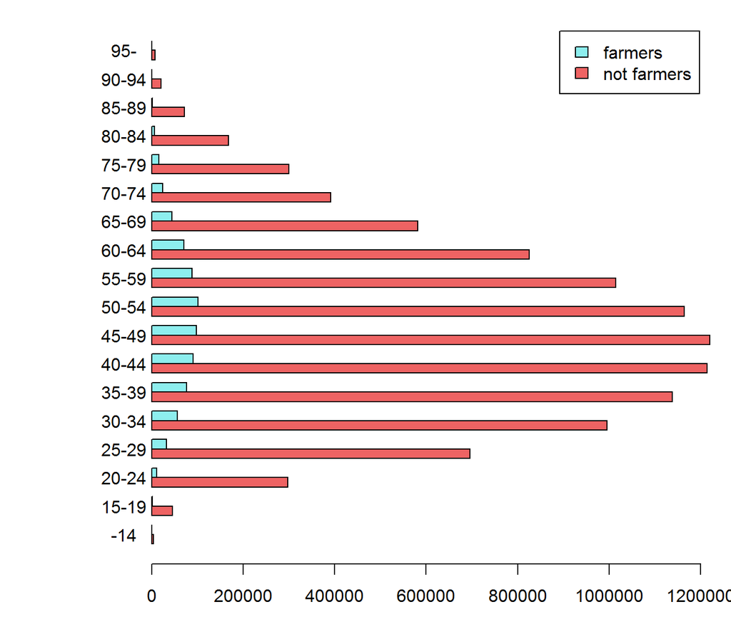

Figure 1: Age distribution of heads of households that are in skilled farming occupation or not - counts

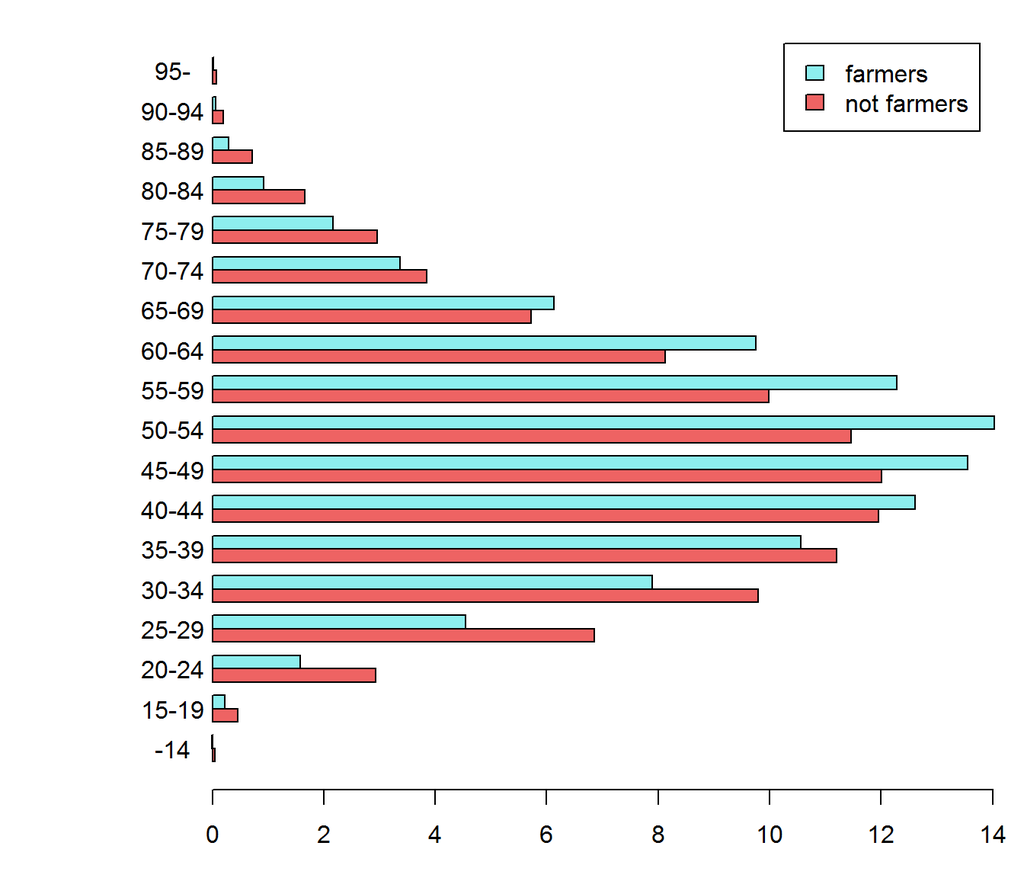

Figure 2: Age distribution of heads of households that are in skilled farming occupation or not - percentages

Table 1: Age distribution of heads of households of type 1 farming (and non farming)

| age.group | non.farm | farm | non.farm.percent | farm.percent |
| --- | --- | --- | --- | --- |
| -14 | 4571 | 80 | 0.05 | 0.01 |
| 15-19 | 45798 | 1571 | 0.45 | 0.22 |
| 20-24 | 298103 | 11322 | 2.93 | 1.57 |
| 25-29 | 696372 | 32695 | 6.86 | 4.54 |
| 30-34 | 995070 | 56817 | 9.80 | 7.89 |
| 35-39 | 1137895 | 76094 | 11.20 | 10.56 |
| 40-44 | 1213701 | 90797 | 11.95 | 12.61 |
| 45-49 | 1220041 | 97682 | 12.01 | 13.56 |
| 50-54 | 1164212 | 101092 | 11.46 | 14.04 |
| 55-59 | 1014522 | 88489 | 9.99 | 12.29 |
| 60-64 | 825515 | 70293 | 8.13 | 9.76 |
| 65-69 | 581725 | 44163 | 5.73 | 6.13 |
| 70-74 | 391311 | 24256 | 3.85 | 3.37 |
| 75-79 | 300226 | 15640 | 2.96 | 2.17 |
| 80-84 | 168396 | 6654 | 1.66 | 0.92 |
| 85-89 | 72279 | 2085 | 0.71 | 0.29 |
| 90-94 | 20366 | 392 | 0.20 | 0.05 |
| 95- | 7449 | 158 | 0.07 | 0.02 |

### Farming HH 2: Head or spouse is skilled farmer

In the second type of “farming households” these are households where:

1. The head or the spouse of the head of the HH is in a farming occupation (ISCO classification category 6: Skilled Agricultural, Forestry and Fishery Workers), AND
2. That person is not an employee. (Their Activity status is either Employer or Contributing family worker)

There are 1167817 such households out of 10877832, so 10.735751 %.

Then we can look at the age distribution of the *heads of these households* - Important!! SO again: this is the age distribution of the heads of household, who may not be farmers, but in that case their spouse is!

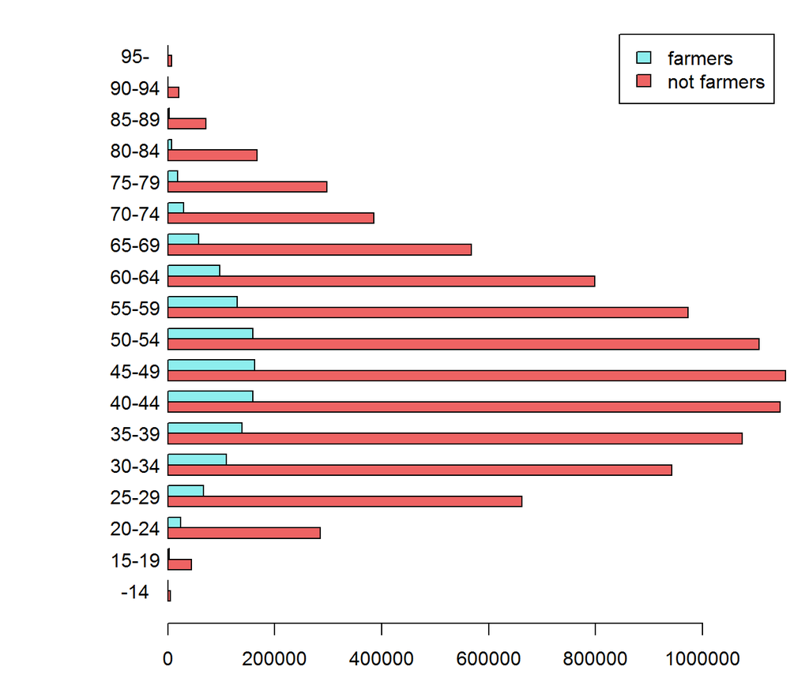

Figure 3: Age distribution of heads of households who are (or their spouses) in skilled farming occupation or not - counts

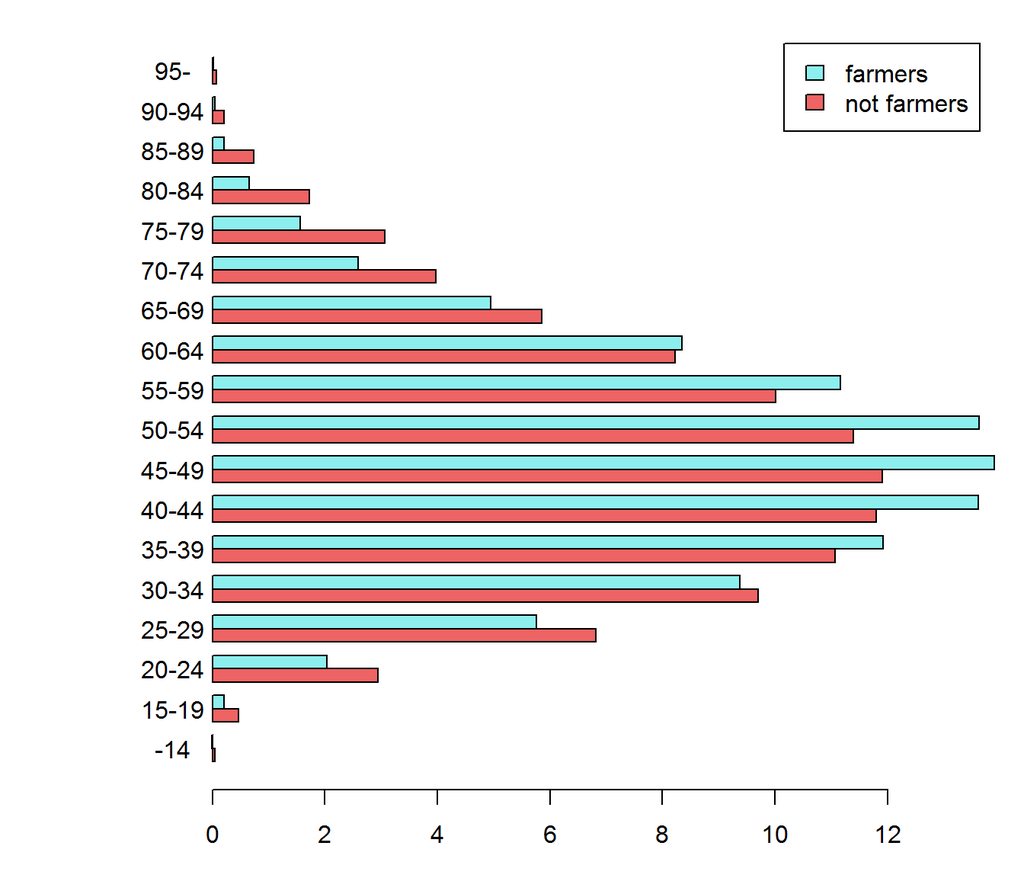

Figure 4: Age distribution of heads of households who are (or their spouses) in skilled farming occupation or not - percentages

Table 2: Age distribution of heads of households of type 2 farming (and non farming)

| age.group | non.farm | farm | non.farm.percent | farm.percent |
| --- | --- | --- | --- | --- |
| -14 | 4561 | 90 | 0.05 | 0.01 |
| 15-19 | 44853 | 2516 | 0.46 | 0.22 |
| 20-24 | 285668 | 23757 | 2.94 | 2.03 |
| 25-29 | 661850 | 67217 | 6.82 | 5.76 |
| 30-34 | 942353 | 109534 | 9.70 | 9.38 |
| 35-39 | 1074810 | 139179 | 11.07 | 11.92 |
| 40-44 | 1145550 | 158948 | 11.80 | 13.61 |
| 45-49 | 1155425 | 162298 | 11.90 | 13.90 |
| 50-54 | 1106123 | 159181 | 11.39 | 13.63 |
| 55-59 | 972633 | 130378 | 10.02 | 11.16 |
| 60-64 | 798303 | 97505 | 8.22 | 8.35 |
| 65-69 | 568161 | 57727 | 5.85 | 4.94 |
| 70-74 | 385325 | 30242 | 3.97 | 2.59 |
| 75-79 | 297577 | 18289 | 3.06 | 1.57 |
| 80-84 | 167326 | 7724 | 1.72 | 0.66 |
| 85-89 | 71893 | 2471 | 0.74 | 0.21 |
| 90-94 | 20233 | 525 | 0.21 | 0.04 |
| 95- | 7371 | 236 | 0.08 | 0.02 |

### Farming HH 3: Any relative in HH is skilled farmer

In the third type of “farming households” these are households where:

1. Any relative in the HH is in a farming occupation (ISCO classification category 6: Skilled Agricultural, Forestry and Fishery Workers), AND
2. That person is not an employee. (Their Activity status is either Employer or Contributing family worker)

There are 4235580 such households out of 10877832, so 38.937722 %.

Then we can look at the age distribution of the *heads of these households* - Important!! SO again: this is the age distribution of the heads of household, who may not be farmers - but someone related to them in the HH is!

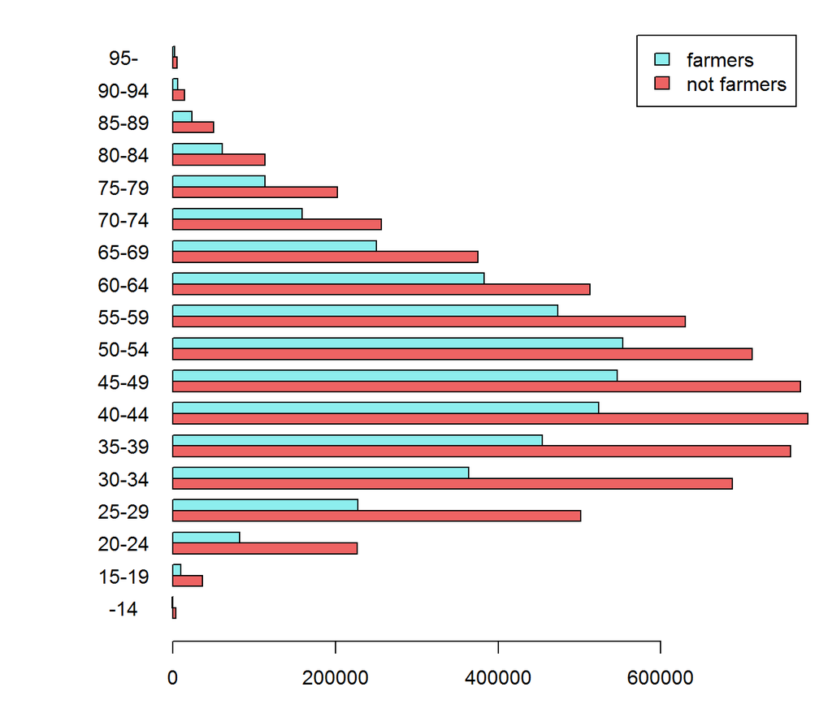

Figure 5: Age distribution of heads of households where at least one relative is in a skilled farming occupation or not - counts

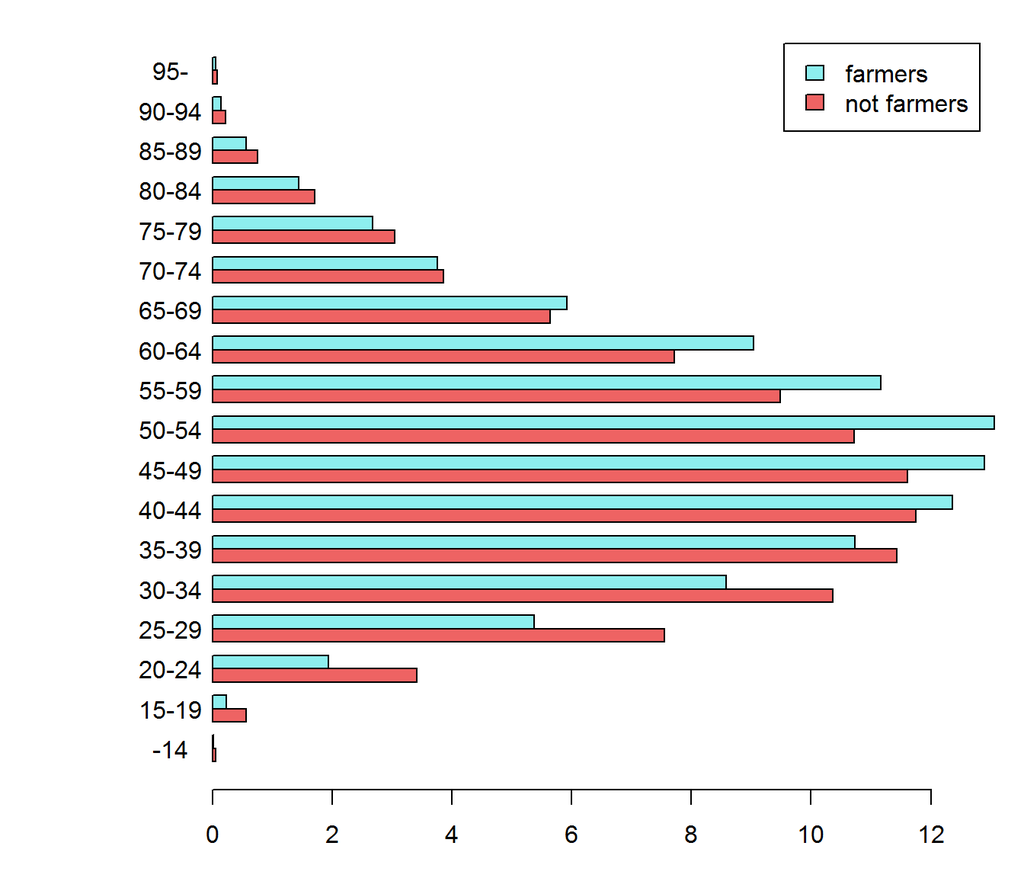

Figure 6: Age distribution of heads of households where at least one relative is in a skilled farming occupation or not - percentages

Table 3: Age distribution of heads of households of type 3 farming (and non farming)

| age.group | non.farm | farm | non.farm.percent | farm.percent |
| --- | --- | --- | --- | --- |
| -14 | 4075 | 576 | 0.06 | 0.01 |
| 15-19 | 37208 | 10161 | 0.56 | 0.24 |
| 20-24 | 227020 | 82405 | 3.42 | 1.95 |
| 25-29 | 501521 | 227546 | 7.55 | 5.37 |
| 30-34 | 688230 | 363657 | 10.36 | 8.59 |
| 35-39 | 759366 | 454623 | 11.43 | 10.73 |
| 40-44 | 780717 | 523781 | 11.75 | 12.37 |
| 45-49 | 771396 | 546327 | 11.61 | 12.90 |
| 50-54 | 712069 | 553235 | 10.72 | 13.06 |
| 55-59 | 629889 | 473122 | 9.48 | 11.17 |
| 60-64 | 512870 | 382938 | 7.72 | 9.04 |
| 65-69 | 375169 | 250719 | 5.65 | 5.92 |
| 70-74 | 256392 | 159175 | 3.86 | 3.76 |
| 75-79 | 202326 | 113540 | 3.05 | 2.68 |
| 80-84 | 113689 | 61361 | 1.71 | 1.45 |
| 85-89 | 50594 | 23770 | 0.76 | 0.56 |
| 90-94 | 14433 | 6325 | 0.22 | 0.15 |
| 95- | 5288 | 2319 | 0.08 | 0.05 |